# Proje Rapor : Biray Altun 210401013

# Q4 : Veri seti ön işlemesi

**State Populations by Youth, Adulthood, and Gender Dataset** tablosunda age_group=All olan ve gender_group=Both olan sütunları kullanacağım.

| population | state |
| --- | --- |
| 4876250 | Alabama |
| 737068 | Alaska |
| 7050299 | Arizona |
| 2999370 | Arkansas |
| 39283497 | California |
| 5610349 | Colorado |
| 3575074 | Connecticut |
| 957248 | Delaware |
| 20901636 | Florida |
| 10403847 | Georgia |

[output cut: 43 more lines]

**GDP per capita in US states Dataset** tablosunda sadece 2017 yılına ait GDP değerlerini ve Area kısımı ayrı bir tablo gibi ayıklandı.

| Area | 2017 |
| --- | --- |
| United States | 51337 |
| Alabama | 37508 |
| Alaska | 63610 |
| Arizona | 39583 |
| Arkansas | 36714 |
| California | 60359 |
| Colorado | 54026 |
| Connecticut | 62633 |
| Delaware | 63955 |
| District of Columbia | 159607 |

[output cut: 50 more lines]

Tablolarda ham veri setleri okundu ve aşağıdaki adımlar uygulandı : *state ve Area sütununu faktör tipine çevir* *Eksik veri temizleme*

**Ön İşleme Raporu: State Populations by Youth, Adulthood, Gender Dataset and GDP per capita in US states Dataset**

state and Area Sütunu: Ham veri setindeki state ve Area sütunu faktör tipine çevrildi.

# Q5 : Veri mühendisliği

**İki tablonun ülkeler bazında işlenebilmesi için birleştirildi ve yeni oluşan tablo aşağıdaki gibi oluşmuştur.**

| state | population | 2017 |
| --- | --- | --- |
| Alabama | 4876250 | 37508 |
| Alaska | 737068 | 63610 |
| Arizona | 7050299 | 39583 |
| Arkansas | 2999370 | 36714 |
| California | 39283497 | 60359 |
| Colorado | 5610349 | 54026 |
| Connecticut | 3575074 | 62633 |
| Delaware | 957248 | 63955 |
| Florida | 20901636 | 39842 |
| Georgia | 10403847 | 45925 |

[output cut: 43 more lines]

# Q6 : Veri analizi

**Eyaletlerin Nüfuslarına ve GDP lerine Göre Kaç tane ve Hangi Tipte Dükkan Açılabileceğini Gösteren Tablo.**

```
##             state store_count premium_count regular_count
## 1         Alabama           3             0             3
## 2          Alaska           1             1             0
## 3         Arizona           4             0             4
## 4        Arkansas           2             0             2
## 5      California          20            10            10
## 6        Colorado           3             2             1
## 7     Connecticut           2             1             1
## 8        Delaware           1             1             0
## 9         Florida          11             0            11
## 10        Georgia           6             0             6
## 11         Hawaii           1             1             0
## 12          Idaho           1             0             1
## 13       Illinois           7             4             3
## 14        Indiana           4             0             4
```

[output cut: 38 more lines]

**Eyaletlerin Nüfuslarına Göre Kaç tane Dükkan Açabileceğimi Gösteren Grafik.**

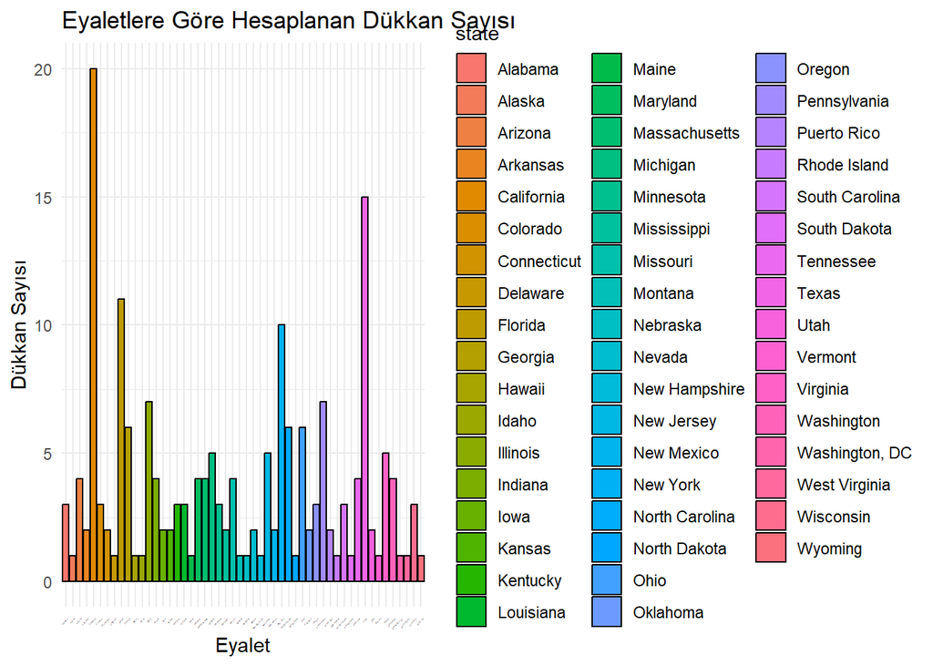